# Рекомендательные системы: напоминание. И снова Shiny

Сегодня мы вспомним о рекомендательных системах, о том, как их строить с помощью R, и продолжим работу с Shiny.

Напоминаю, что мы используем пакет `recommenderlab`

```r
library(recommenderlab)
```

Построим систему, которая будет рекомендовать фильмы на основе базы оценок. В качестве исходных данных используем датасет MovieLense

```r
data(MovieLense)
MovieLense
```

```
## 943 x 1664 rating matrix of class 'realRatingMatrix' with 99392 ratings.
```

- строка = пользователь, столбец = фильм, на пересечении – оценки
- полная матрица 943*1664, но с большим числом пропущенных значений (каждый пользователь оценивает существенно меньше, чем 1664 фильмов), поэтому используется более компактный способ хранения – `realRatingMatrix`.
- **?:** можно ли с объектом класса `realRatingMatrix` использовать методы пакета dplyr? А базовые методы вроде `mean()` или `colSums()`?

### Построение рекомендательной модели

Сначала подготовим данные, в частности, уберем те, что являются нерелевантными.

- чем могут “мешать” фильм с малым числом оценок?
- какие могут быть проблемы в рекомендации тому пользователю, кто поставил мало оценок?
- что делать в случае “холодного старта”? (т.е. когда оценок мало)

Количество оценок у фильма можно посчитать с помощью функции colCounts(), а количество оценок, поставленных одним пользователем – с помощью rowCounts(). Эти функции не учитывают 0, которыми обозначены отсутствющие оценки.

Отберем только строки и столбцы с нужным количеством оценок

```r
ratings_movies <- MovieLense[rowCounts(MovieLense) > 50, colCounts(MovieLense) > 100]
```

Рассмотрим распределение средних оценок пользователя

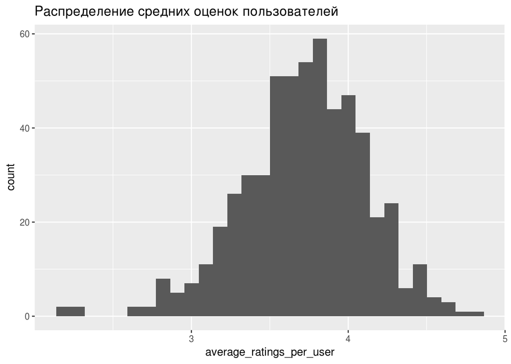

```r
library(ggplot2)
average_ratings_per_user <- rowMeans(ratings_movies)
ggplot()+geom_histogram(aes(x=average_ratings_per_user)) +
ggtitle("Распределение средних оценок пользователей")
```

Для построения рекомендаций применим **метод коллаборативной фильтрации**

- как можно посчитать близость, т.е. найти «похожих» людей или схожие фильмы?

Метод коллаборативной фильтрации

- вычислить похожесть всех пар фильмов
- для каждого фильма найти k наиболее похожих
- для каждого пользователя определить фильмы, наиболее близкие к тем, которые он оценил

Возможны разные методы построения модели. Рассмотрим метод IBCF (“Recommender based on item-based collaborative filtering (real data).”)

Построим рекомендательную модель

```r
recc_model <- Recommender(data = ratings_movies, method = "IBCF", parameter = list(k = 30))
```

Детали этой модели можно получить с помощью метода getModel(), например, матрицу схожести

```r
model_details <- getModel(recc_model)
model_details$description
```

```
## [1] "IBCF: Reduced similarity matrix"
```

```r
model_details$sim[1:5, 1:5]
```

```
## 5 x 5 sparse Matrix of class "dgCMatrix"
##                       Toy Story (1995) GoldenEye (1995) Get Shorty (1995)
## Toy Story (1995)                     .                .                 .
## GoldenEye (1995)                     .                .                 .
## Get Shorty (1995)                    .                .                 .
## Twelve Monkeys (1995)                .                .                 .
## Babe (1995)                          .                .                 .
##                       Twelve Monkeys (1995) Babe (1995)
## Toy Story (1995)                          .           .
## GoldenEye (1995)                          .           .
## Get Shorty (1995)                         .           .
## Twelve Monkeys (1995)                     .           .
## Babe (1995)                               .           .
```

Рекомендации

- для каждого пользователя извлекаются те фильмы, которые он оценил
- для каждого из фильмов находятся похожие фильмы
- затем фильмы упорядочиваются согласно весам, где вес каждой рекомендации (фильма) вычисляется на основе оценок пользователя и показателей схожести фильмов (взвешенная сумма)

```r
recc_predicted <- predict(object = recc_model, newdata = ratings_movies[1:10,], n = 6)
recc_predicted
```

```
## Recommendations as 'topNList' with n = 6 for 10 users.
```

Посмотрим на результат

```r
str(recc_predicted)
```

```
## Formal class 'topNList' [package "recommenderlab"] with 4 slots
##   ..@ items     :List of 10
##   .. ..$ 1 : int [1:6] 305 260 183 208 257 193
##   .. ..$ 2 : int [1:6] 2 5 8 12 13 17
##   .. ..$ 3 : int [1:6] 5 20 27 42 81 84
##   .. ..$ 5 : int [1:6] 330 212 208 193 120 174
##   .. ..$ 6 : int [1:6] 40 297 291 17 310 326
##   .. ..$ 7 : int [1:6] 177 171 202 161 127 326
##   .. ..$ 8 : int [1:6] 10 11 45 47 53 63
##   .. ..$ 10: int [1:6] 60 114 109 237 25 330
##   .. ..$ 11: int [1:6] 321 256 235 293 131 71
##   .. ..$ 12: int [1:6] 21 28 46 57 129 161
##   ..@ ratings   :List of 10
##   .. ..$ 1 : num [1:6] 4.63 4.53 4.48 4.47 4.47 ...
##   .. ..$ 2 : num [1:6] 5 5 5 5 5 5
##   .. ..$ 3 : num [1:6] 5 5 5 5 5 5
##   .. ..$ 5 : num [1:6] 4.67 4.65 4.59 4.47 4.4 ...
##   .. ..$ 6 : num [1:6] 4.61 4.53 4.52 4.45 4.42 ...
##   .. ..$ 7 : num [1:6] 4.84 4.72 4.61 4.59 4.58 ...
##   .. ..$ 8 : num [1:6] 5 5 5 5 5 5
##   .. ..$ 10: num [1:6] 4.83 4.82 4.79 4.75 4.75 ...
##   .. ..$ 11: num [1:6] 4.2 4.18 4.17 4.17 4.13 ...
##   .. ..$ 12: num [1:6] 5 5 5 5 5 5
##   ..@ itemLabels: chr [1:332] "Toy Story (1995)" "GoldenEye (1995)" "Get Shorty (1995)" "Twelve Monkeys (1995)" ...
##   ..@ n         : int 6
```

Слоты (доступ через символ @)

- items – содержит индексы рекомендованных фильмов для каждого пользователя
- itemLabels – названия фильмов
- ratings – рейтинги рекомендаций
- n – число рекомендаций

Рекомендации для первого пользователя

```r
recc_user_1 <- recc_predicted@items[[1]]
recc_user_1
```

```
## [1] 305 260 183 208 257 193
```

```r
movies_user_1 <- recc_predicted@itemLabels[recc_user_1]
movies_user_1
```

```
## [1] "Seven Years in Tibet (1997)" "Casablanca (1942)"
## [3] "English Patient, The (1996)" "G.I. Jane (1997)"
## [5] "Vertigo (1958)"              "L.A. Confidential (1997)"
```

### Переходим к Shiny:

#### Часть 1

Построить приложение, в котором можно задавать границы отсечения нерелевантных данных

- сформируйте интерфейс приложения, в котором два поля для ввода
  - минимум оценок у фильма (например, sliderInput)
  - минимум оценок у пользователя (пусть тоже sliderInput)
- а в качестве вывода – график со средней оценкой по оставшимся фильмам и пользователям
- реализуйте серверную часть
  - что нужно изменить в нашем коде?

```r
library(ggplot2)
data(MovieLense)

ratings_movies <- MovieLense[rowCounts(MovieLense) > 50, colCounts(MovieLense) > 100]

average_ratings_per_user <- rowMeans(ratings_movies)
ggplot()+geom_histogram(aes(x=average_ratings_per_user)) +
ggtitle("Распределение средних оценок пользователей")
```

- hint: загрузите данные и пакеты ДО функции, описывающей действия сервера

```r
library(shiny)

ui <- fluidPage(...)

library(ggplot2)
data(MovieLense)

server <- function(input, output) { ... }

shinyApp(ui = ui, server = server)
```

#### Часть 2

**Ваша очередь:**

Постройте рекомендательную систему на основе схожести между пользователями, а не между фильмами (метод UBCF вместо IBCF).